# Pratical Machine Learning Peers Assignment

Walter Trabucco

## PML Prediction Assignment Context

Using devices such as Jawbone Up, Nike FuelBand, and Fitbit it is now possible to collect a large amount of data about personal activity relatively inexpensively. These type of devices are part of the quantified self movement - a group of enthusiasts who take measurements about themselves regularly to improve their health, to find patterns in their behavior, or because they are tech geeks. One thing that people regularly do is quantify how much of a particular activity they do, but they rarely quantify how well they do it. In this project, your goal will be to use data from accelerometers on the belt, forearm, arm, and dumbell of 6 participants. They were asked to perform barbell lifts correctly and incorrectly in 5 different ways. More information is available from the website here: http://groupware.les.inf.puc-rio.br/har (see the section on the Weight Lifting Exercise Dataset).

## Data

### Data source

The training data for this project are available here:

https://d396qusza40orc.cloudfront.net/predmachlearn/pml-training.csv

The test data are available here:

https://d396qusza40orc.cloudfront.net/predmachlearn/pml-testing.csvsee

### Load and cleaning data

You load both dataset `dataori*` for training and cross-validation and `valida*` than basically contains the test set for final 20 predictions which will be submitted. In the code the idea is that everytime you trasform `dataori*` you have to apply the same trasformation to `valida*` test set.

```r
dataori<-read.csv("pml-training.csv")
validaori<-read.csv("pml-testing.csv")
n<-nrow(dataori)
str(dataori)
```

```
## 'data.frame':    19622 obs. of  160 variables:
##  $ X                       : int  1 2 3 4 5 6 7 8 9 10 ...
##  $ user_name               : Factor w/ 6 levels "adelmo","carlitos",..: 2 2 2 2 2 2 2 2 2 2 ...
##  $ raw_timestamp_part_1    : int  1323084231 1323084231 1323084231 1323084232 1323084232 1323084232 1323084232 1323084232 1323084232 1323084232 ...
##  $ raw_timestamp_part_2    : int  788290 808298 820366 120339 196328 304277 368296 440390 484323 484434 ...
##  $ cvtd_timestamp          : Factor w/ 20 levels "02/12/2011 13:32",..: 9 9 9 9 9 9 9 9 9 9 ...
##  $ new_window              : Factor w/ 2 levels "no","yes": 1 1 1 1 1 1 1 1 1 1 ...
##  $ num_window              : int  11 11 11 12 12 12 12 12 12 12 ...
##  $ roll_belt               : num  1.41 1.41 1.42 1.48 1.48 1.45 1.42 1.42 1.43 1.45 ...
##  $ pitch_belt              : num  8.07 8.07 8.07 8.05 8.07 8.06 8.09 8.13 8.16 8.17 ...
##  $ yaw_belt                : num  -94.4 -94.4 -94.4 -94.4 -94.4 -94.4 -94.4 -94.4 -94.4 -94.4 ...
##  $ total_accel_belt        : int  3 3 3 3 3 3 3 3 3 3 ...
##  $ kurtosis_roll_belt      : Factor w/ 397 levels "","-0.016850",..: 1 1 1 1 1 1 1 1 1 1 ...
##  $ kurtosis_picth_belt     : Factor w/ 317 levels "","-0.021887",..: 1 1 1 1 1 1 1 1 1 1 ...
##  $ kurtosis_yaw_belt       : Factor w/ 2 levels "","#DIV/0!": 1 1 1 1 1 1 1 1 1 1 ...
```

[output cut: 86 more lines]

From the `str()` function you can deduced that we have a large number of covarinats with a lot `NA` value. The data trasformation are:

- remove columns 1 to 6 which are just reference information
- eliminate the covariants with more 95% of `NA` values
- eliminate the near zero variance covariants

```r
# remove columns 1 to 6
dataps<-dataori[,7:160]
validaps<-validaori[7:160]
# look for covariants with less 95% of NA values
nis_na<-colSums(is.na(dataps))/n<0.95
# apply trasformation both training and test set
datap1<-dataps[,nis_na]
validap1<-validaps[,nis_na]
# look for near zero variance covariants
nzv<-nearZeroVar(datap1,saveMetrics = FALSE, allowParallel = TRUE,names=FALSE)
# remove nzv covariants
datap2<-datap1[,-nzv]
validap2<-validap1[,-nzv]
```

## Data partition

Now starting from `datap2`, data training without almost NA and near zero variance covariants, we generate a *training* partition plus a *testing* partition for the cross-validation using `classe` as outcome covariant.

```r
data<-datap2
set.seed(32323)
indextrain<-createDataPartition(y=data$classe,p=0.7,list=FALSE)
training<-data[indextrain,]
testing<-data[-indextrain,]
```

## Fit the models

The issue is a classification problem and based the Coursera course you know one of the best methos for that problem is *Random Forest*, `method="rf"`. Anyway we try to use also`method="rpart"` and compare them.

### Rpart - Recursive Partitioning and Regression Trees

```r
startRP<-proc.time()
trControlRP<-trainControl(method = "cv",number = 5)
modFitRP<-train(classe ~ ., method="rpart", data=training,trControl=trControlRP)
endRF<-proc.time()
tRP<-(endRF-startRP)/60
```

We use 0.1063333 min to fit this tree model:

[figure not shown]

```r
library(rattle)
fancyRpartPlot(modFitRP$finalModel)
```

### Random Forest

```r
startRF<-proc.time()
trControlRF<-trainControl(method = "cv",number = 5,allowParallel=TRUE)
modFitRF<-train(classe ~ ., method="rf", data=training,trControl=trControlRF,verbose=FALSE,allowParallel=TRUE)
endRF<-proc.time()
tRF<-(endRF-startRF)/60
```

We use 11.8151667 min to fit a random forest model with these relavant covariants:

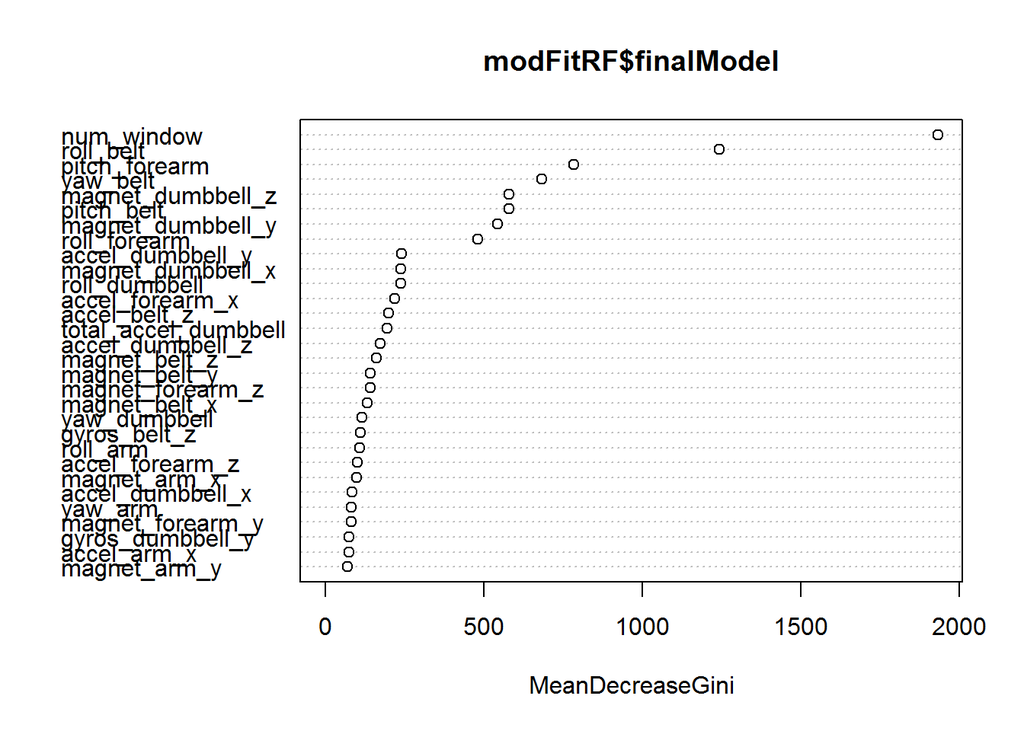

```r
varImpPlot(modFitRF$finalModel)
```

## Cross Validation and comparison

```r
predRP<-predict(modFitRP,testing)
predRF<-predict(modFitRF,testing)
```

```r
RP<-confusionMatrix(predRP,testing$classe)
RP
```

```
## Confusion Matrix and Statistics
##
##           Reference
## Prediction    A    B    C    D    E
##          A 1521  459  470  423  101
##          B   20  391   33  161   82
##          C  131  289  523  341  221
##          D    0    0    0    0    0
##          E    2    0    0   39  678
##
## Overall Statistics
##
##                Accuracy : 0.529
##                  95% CI : (0.5161, 0.5418)
##     No Information Rate : 0.2845
##     P-Value [Acc > NIR] : < 2.2e-16
##
##                   Kappa : 0.3856
##  Mcnemar's Test P-Value : < 2.2e-16
##
## Statistics by Class:
##
##                      Class: A Class: B Class: C Class: D Class: E
## Sensitivity            0.9086  0.34328  0.50975   0.0000   0.6266
## Specificity            0.6550  0.93763  0.79790   1.0000   0.9915
## Pos Pred Value         0.5114  0.56914  0.34751      NaN   0.9430
## Neg Pred Value         0.9474  0.85610  0.88516   0.8362   0.9218
## Prevalence             0.2845  0.19354  0.17434   0.1638   0.1839
## Detection Rate         0.2585  0.06644  0.08887   0.0000   0.1152
## Detection Prevalence   0.5054  0.11674  0.25573   0.0000   0.1222
## Balanced Accuracy      0.7818  0.64046  0.65382   0.5000   0.8090
```

```r
RF<-confusionMatrix(predRF,testing$classe)
RF
```

```
## Confusion Matrix and Statistics
##
##           Reference
## Prediction    A    B    C    D    E
##          A 1674    3    0    0    0
##          B    0 1136    3    0    0
##          C    0    0 1023    2    0
##          D    0    0    0  962    1
##          E    0    0    0    0 1081
##
## Overall Statistics
##
##                Accuracy : 0.9985
##                  95% CI : (0.9971, 0.9993)
##     No Information Rate : 0.2845
##     P-Value [Acc > NIR] : < 2.2e-16
##
##                   Kappa : 0.9981
##  Mcnemar's Test P-Value : NA
##
## Statistics by Class:
##
##                      Class: A Class: B Class: C Class: D Class: E
## Sensitivity            1.0000   0.9974   0.9971   0.9979   0.9991
## Specificity            0.9993   0.9994   0.9996   0.9998   1.0000
## Pos Pred Value         0.9982   0.9974   0.9980   0.9990   1.0000
## Neg Pred Value         1.0000   0.9994   0.9994   0.9996   0.9998
## Prevalence             0.2845   0.1935   0.1743   0.1638   0.1839
## Detection Rate         0.2845   0.1930   0.1738   0.1635   0.1837
## Detection Prevalence   0.2850   0.1935   0.1742   0.1636   0.1837
## Balanced Accuracy      0.9996   0.9984   0.9983   0.9989   0.9995
```

As you can the *Random Forest* accuracy 0.9984707 is larger the *Rpart* accuracy 0.528972. In other word the cross-validation using a partition `testing` means that the current Random Forest model is better of Rpart one where we should try to use different combination of covariants.

## Predict to submit

So according to the trasformation performed on `dataori*` we use `validap2` as final dataset to predict value for submition to the Coursera course using the Random Forest model `modFitRF`:

```r
predFinalRF<-predict(modFitRF,validap2)
predFinalRF
```

```
##  [1] B A B A A E D B A A B C B A E E A B B B
## Levels: A B C D E
```